# Contrast coding

**Different ways to explore categorical predictors**

Professor Andy Field, University of Sussex

Links: [rush subdivisions](https://profandyfield.github.io/statistics_lectures/ds_07_contrasts/media/rush_subdivisions.mp3) | [bsky.app](https://bsky.app/profile/profandyfield.bsky.social) | [youtube.com](https://www.youtube.com/user/ProfAndyField) | discoveringstatistics.com | discovr.rocks | statisticsadventure.com

## About this version

This is a plain-text version of the lecture slides. Each slide starts with a heading such as “Slide 5”, and the numbers match the slide numbers shown in the lecture. Content that appeared one piece at a time, in columns or in tabs is shown in reading order. Videos and interactive apps are given as links.

## Slide 2: Learning outcomes

- Explain the different ways to break down categorical predictors in a linear model
  - Planned contrasts/comparisons)
  - Choosing contrasts
  - Contrast coding
- *Post hoc* tests
- Polynomial contrasts (trend analysis)

## Slide 3


## Slide 4

## Slide 5: Contrast coding

- The *F*-statistic tests the overall fit of the model
  - i.e. It is a general test of model fits/whether group means significantly differ
- Model parameters tells us about specific differences between means
  - Dummy coding compares each category to a baseline
- What do we do when dummy coding does not reflect our *a priori* hypotheses?

## Slide 6: Options for breaking down categorical predictors

- Orthogonal contrasts (contrast coding)
- Hypothesis driven
- Planned *a priori*
- Control Type I error rate
- *Post hoc* tests
  - Not planned (not hypothesis driven)
  - Compare all pairs of means
  - Multiple *t*-tests adjusted for the number of tests
- Trend analysis
  - Useful only for ordered means

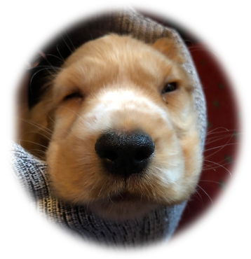

## Slide 7

Video clip: [milton insert puppies](https://profandyfield.github.io/statistics_lectures/ds_07_contrasts/media/milton_insert_puppies.mp4)

## Slide 8: A puppy-tastic example

- A puppy therapy RCT in which we randomized people into three groups:
  - A control group
  - 15 minutes of puppy therapy
  - 30 minutes of puppy contact
- The outcome is happiness (0 = unhappy) to 10 (happy).
- Predictions:
  - Any form of puppy therapy should be better than the control (i.e. higher happiness scores)
  - A dose-response hypothesis that as exposure time increases (from 15 to 30 minutes) happiness will increase too.

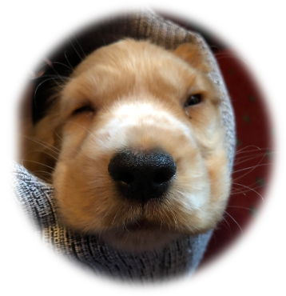

## Slide 9: Load and Look

|  | No puppies | 15 mins | 30 mins |
| --- | --- | --- | --- |
|  | 3 | 5 | 7 |
|  | 2 | 2 | 4 |
|  | 1 | 4 | 5 |
|  | 1 | 2 | 3 |
|  | 4 | 3 | 6 |
| Mean | 2.20 | 3.20 | 5.00 |
| Variance (*s*<sup>2</sup>) | 1.70 | 1.70 | 2.50 |
| Standard deviation (*s*) | 1.30 | 1.30 | 1.58 |

$\text{Overall mean (} \bar{X}_\text{grand}\text{)} = 3.467$

## Slide 10: The general linear model

### Dummy coding

| Therapy group | Long (30 mins vs. no puppies) | Short 1 (15 mins vs. no puppies) |
| --- | --- | --- |
| No Puppies | 0 | 0 |
| 15 mins | 0 | 1 |
| 30 mins | 1 | 0 |

$$\begin{aligned} \text{Happiness}_i &= \hat{b}_0 + \hat{b}_1\text{Long}_i + \hat{b}_2\text{Short}_i + e_i \end{aligned}$$

## Slide 11: Visualize the ‘dummy’ model

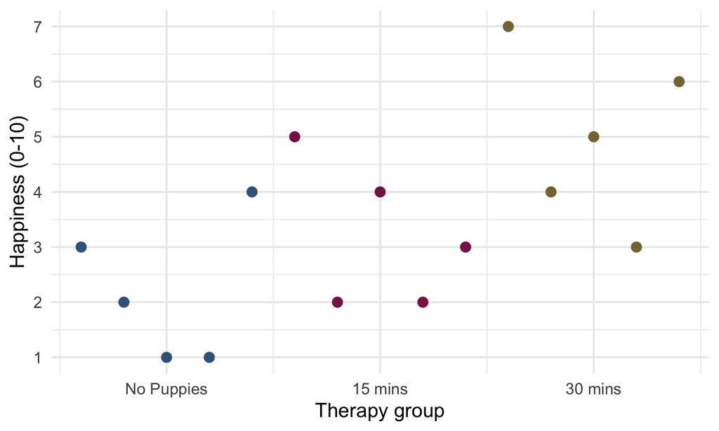

## Slide 12: Visualize the ‘dummy’ model

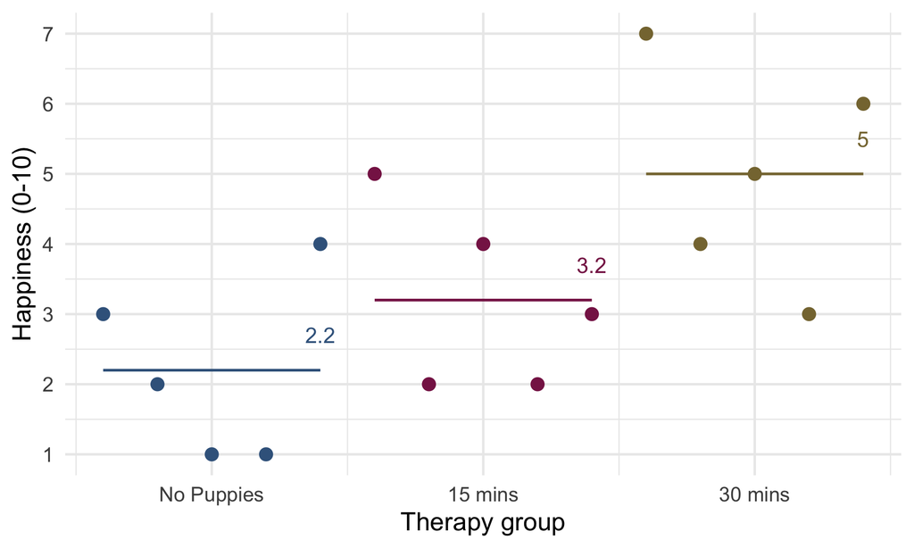

## Slide 13: Visualize the ‘dummy’ model

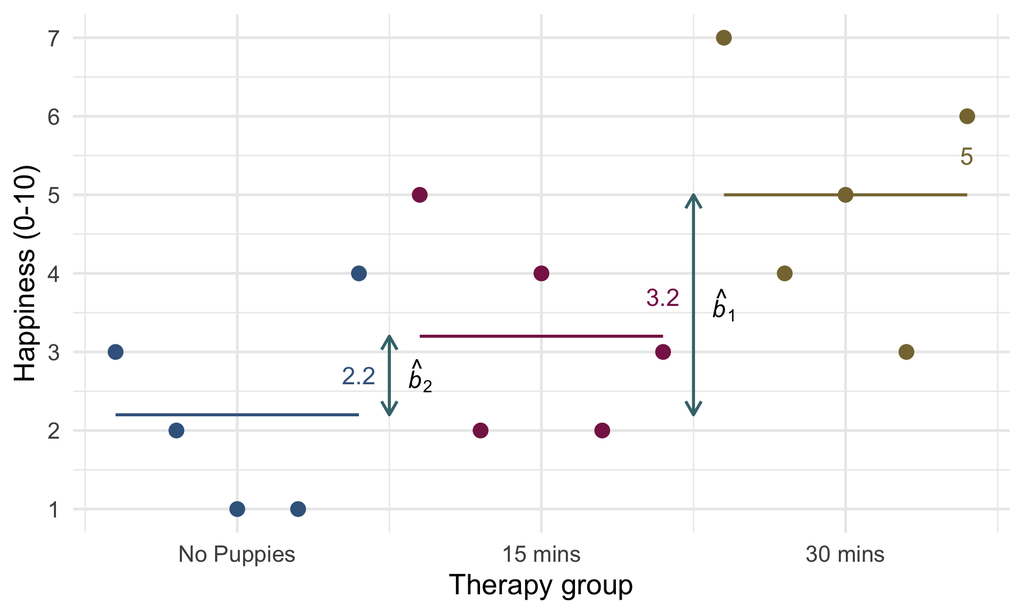

## Slide 14: Fit the model

$$\begin{aligned} \hat{\text{Happiness}}_i &= \hat{b}_0 + \hat{b}_1\text{Long}_i + \hat{b}_2\text{Short}_i \end{aligned}$$

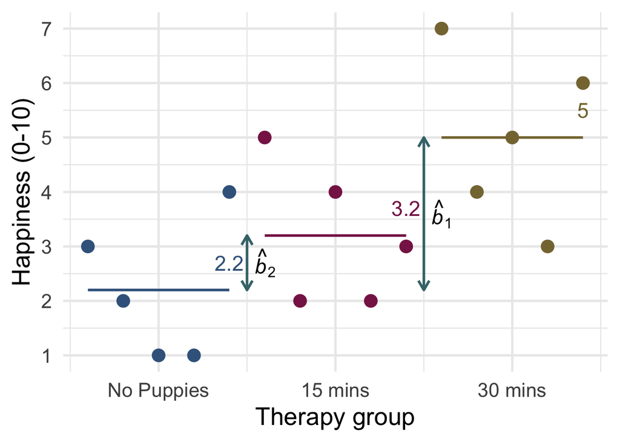

$$\begin{aligned} \hat{b}_0 &= \bar{X}_\text{No puppies} = 2.2 \\ \hat{b}_1 &= 5.0-2.2 = 2.8 \\ \hat{b}_2 &= 3.2-2.2 = 1.0 \end{aligned}$$

## Slide 15: Evaluate fit

```r
# get F
anova(puppy_lm) |>
  model_parameters(es_type = "omega", ci = 0.95) |>
  display()
```

| Parameter | Sum_Squares | df | Mean_Square | F | p | Omega2 | Omega2 95% CI |
| --- | --- | --- | --- | --- | --- | --- | --- |
| dose | 20.13 | 2 | 10.07 | 5.12 | 0.025 | 0.35 | (0.00, 1.00) |
| Residuals | 23.60 | 12 | 1.97 |  |  |  |  |

```r
# get R^2
model_performance(puppy_lm) |>
  display()
```

| AIC | AICc | BIC | R2 | R2 (adj.) | RMSE | Sigma |
| --- | --- | --- | --- | --- | --- | --- |
| 57.4 | 61.4 | 60.2 | 0.46 | 0.37 | 1.25 | 1.40 |

## Slide 16: Evaluate assumptions

```r
check_model(puppy_lm)
```

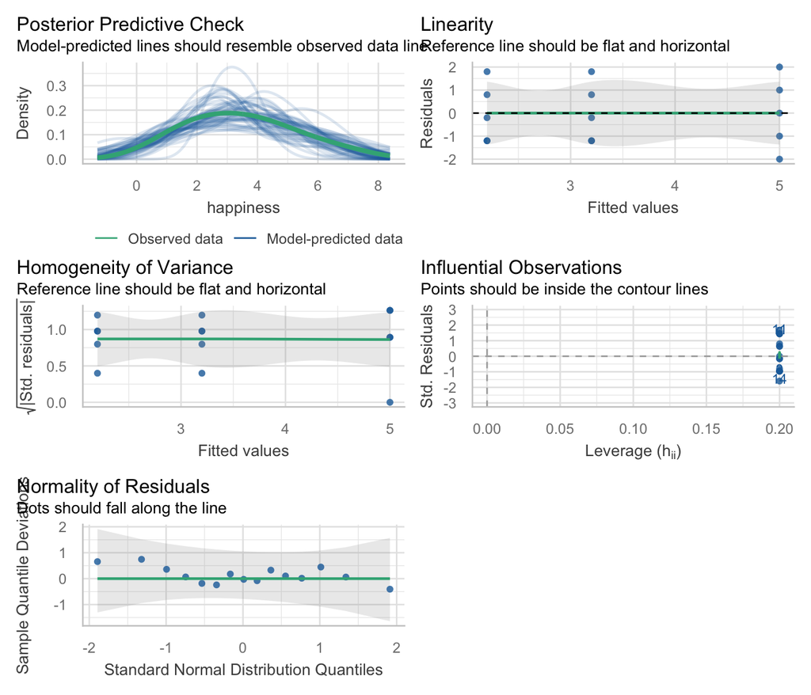

[figure not shown]

## Slide 17: Interpret parameter estimates, CIs and tests

```r
model_parameters(puppy_lm) |>
  display()
```

| Parameter | Coefficient | SE | 95% CI | t(12) | p |
| --- | --- | --- | --- | --- | --- |
| (Intercept) | 2.20 | 0.63 | (0.83, 3.57) | 3.51 | 0.004 |
| dose (15 mins) | 1.00 | 0.89 | (-0.93, 2.93) | 1.13 | 0.282 |
| dose (30 mins) | 2.80 | 0.89 | (0.87, 4.73) | 3.16 | 0.008 |

[figure not shown]

## Slide 18: Planned contrasts

- The variability explained by the model, SS<sub>M</sub> is due to participants being assigned to different groups
  - This variability sometimes represents an experimental manipulation
- This variability (SS<sub>M</sub>) can be broken down further to test specific hypotheses about which groups might differ
- We break down the variance according to hypotheses made *a priori* (before the experiment)
- It’s like cutting up a cake (yum yum!)

## Slide 19

Video clip: [partitioning chocolate silent](https://profandyfield.github.io/statistics_lectures/ds_07_contrasts/media/partitioning_chocolate_silent.mp4)

## Slide 20: The cake analogy again

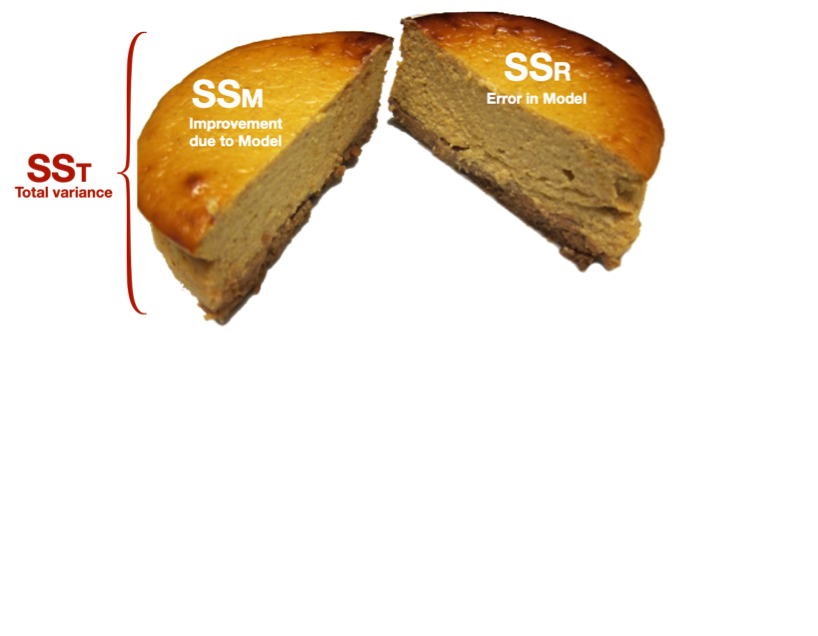

## Slide 21: The cake analogy again

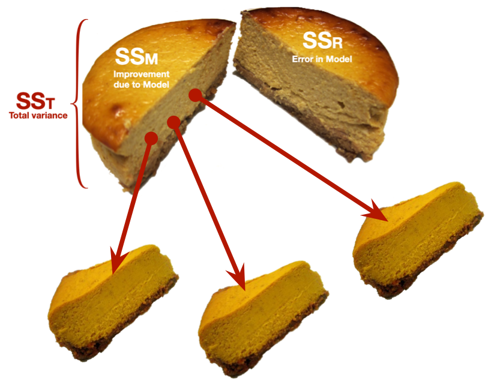

## Slide 22: Choosing contrasts

- Independent
  - To control Type I error rates contrasts must be independent (they must test unique hypotheses)
  - If a group is singled out in a contrast, then that group should not be used in any subsequent contrasts
- Only 2 Chunks
  - Each contrast should compare only 2 chunks of variation (why?)
- *K*-1
  - You should always end up with one less contrast than the number of groups

## Slide 23: How do I choose contrasts?

> **Note: Statis-tip**
> - Most experimental designs typically have one or more control groups
> - The logic of control groups means that we expect scores within them to differ from those in the groups we’ve manipulated
> - The first contrast will usually compare any control conditions (chunk 1) with any experimental ones (chunk 2)

## Slide 24

Video clip: [milton slideshow](https://profandyfield.github.io/statistics_lectures/ds_07_contrasts/media/milton_slideshow.mp4)

## Slide 25: Hypotheses

> **Caution: Think about it!**

> Hypothesis 1:
> - People who have puppy therapy will be happier (have have higher happiness scores) than those who don’t
> - Control $\ne$ (15 mins, 30 mins)

> **Caution: Think about it!**

> Hypothesis 2:
> - People receiving a high dose of puppy therapy (30 mins) will be happier than those receiving a low dose (15 mins)
> - 15 mins $\ne$ 30 mins

## Slide 26

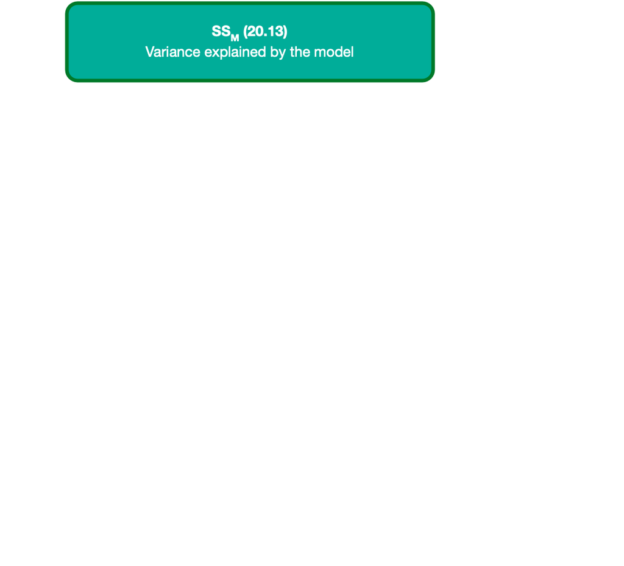

## Slide 27

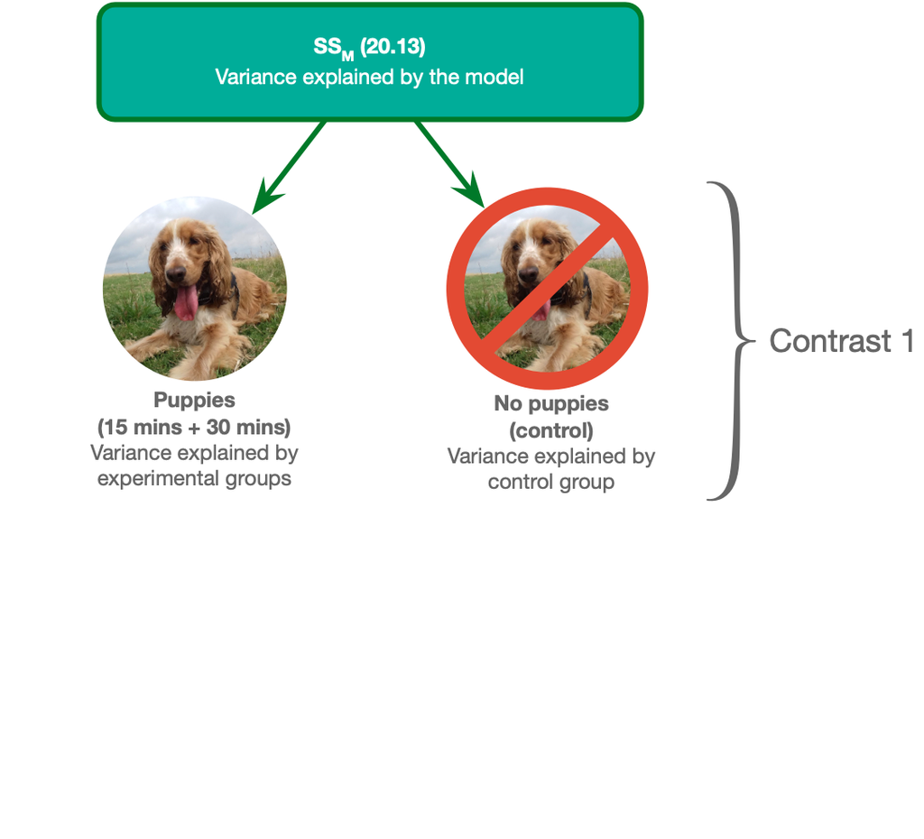

## Slide 28

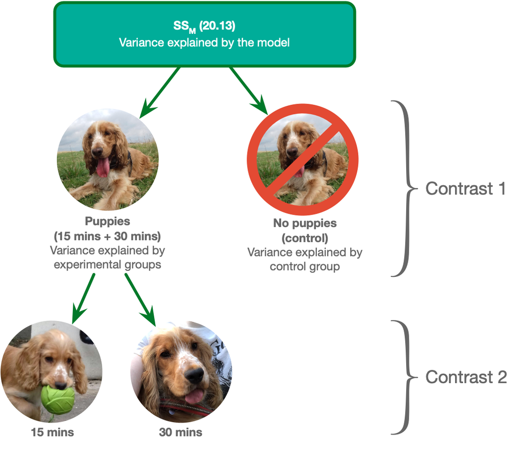

## Slide 29

[figure not shown]

## Slide 30

[figure not shown]

## Slide 31

[figure not shown]

## Slide 32

[figure not shown]

## Slide 33

[figure not shown]

## Slide 34

[figure not shown]

## Slide 35

[figure not shown]

## Slide 36

[figure not shown]

## Slide 37: Coding planned contrasts

- Rule 1
  - Groups coded with positive weights compared to groups coded with negative weights
- Rule 2
  - The sum of weights for a comparison should be zero
- Rule 3
  - If a group is not involved in a comparison, assign it a weight of zero
- Rule 4
  - For a given contrast, the **initial weight** assigned to the group(s) in one chunk of variation should be equal to the number of groups in the opposite chunk of variation
- Rule 5
  - To get the **final weight**, divide the initial weights by the number of groups with non-zero weights

## Slide 38

[figure not shown]

## Slide 39

[figure not shown]

## Slide 40

[figure not shown]

## Slide 41

[figure not shown]

## Slide 42

[figure not shown]

## Slide 43

[figure not shown]

## Slide 44

[figure not shown]

## Slide 45

[figure not shown]

## Slide 46

[figure not shown]

## Slide 47

[figure not shown]

## Slide 48

Video clip: [lazinc durt your time will come](https://profandyfield.github.io/statistics_lectures/ds_07_contrasts/media/lazinc_durt_your_time_will_come.mp4)

## Slide 49: What the coding does

### Dummy coding

| Therapy group | Long (30 mins vs. no puppies) | Short 1 (15 mins vs. no puppies) |
| --- | --- | --- |
| No Puppies | 0 | 0 |
| 15 mins | 0 | 1 |
| 30 mins | 1 | 0 |

### Contrast coding

| Therapy group | Contrast 1 (Puppies vs. no puppies) | Contrast 2 (15 mins vs. 30 mins) |
| --- | --- | --- |
| No Puppies | -2/3 | 0 |
| 15 mins | 1/3 | -1/2 |
| 30 mins | 1/3 | 1/2 |

## Slide 50

### The ‘dummy’ model

$$\begin{aligned} \hat{\text{Happiness}}_i &= \hat{b}_0 + \hat{b}_1\text{Long}_i + \hat{b}_2\text{Short}_i \\ \hat{\text{Happiness}}_i &= \hat{b}_0 + \hat{b}_1\text{30 vs. control}_i + \hat{b}_2\text{15 vs.control}_i\\ \end{aligned}$$

### The ‘contrast’ model

$$\begin{aligned} \hat{\text{Happiness}}_i &= \hat{b}_0 + \hat{b}_1\text{Contrast 1}_i + \hat{b}_2\text{Contrast 2}_i \\ \hat{\text{Happiness}}_i &= \hat{b}_0 + \hat{b}_1\text{Therapy vs. control}_i + \hat{b}_2\text{15 vs. 30 mins}_i \\ \end{aligned}$$

## Slide 51: Visualize the ‘dummy’ model

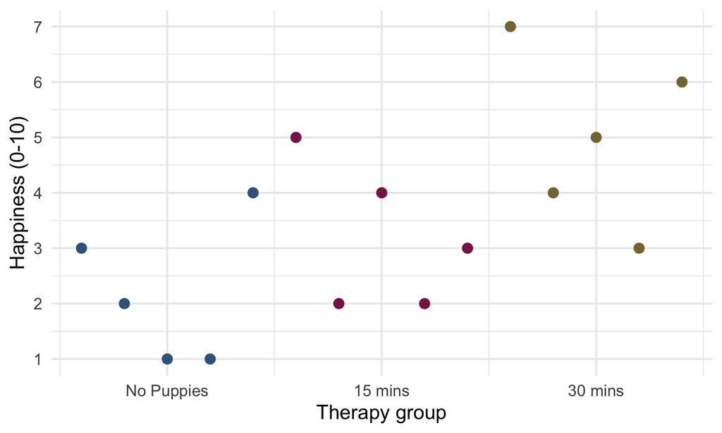

## Slide 52: Visualize the ‘dummy’ model

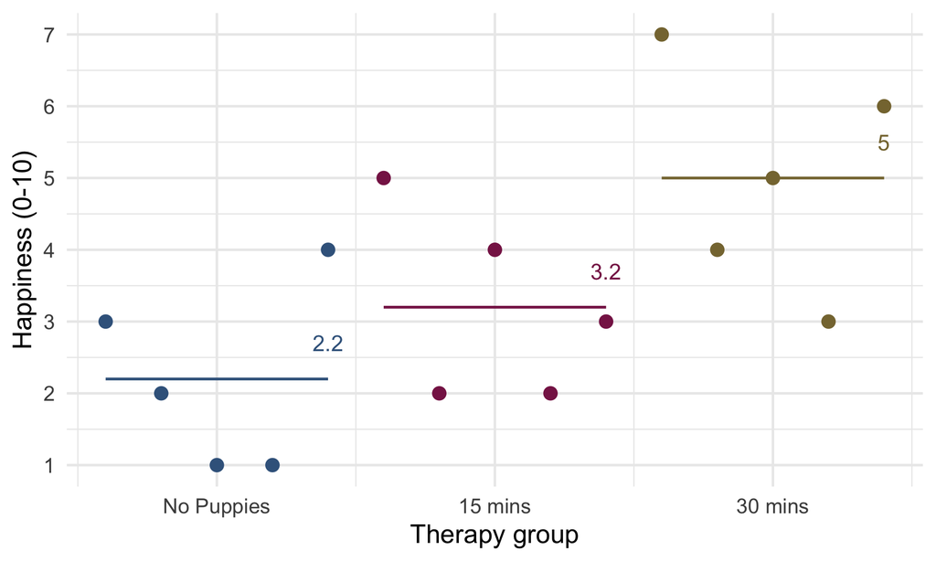

## Slide 53: Visualize the ‘dummy’ model

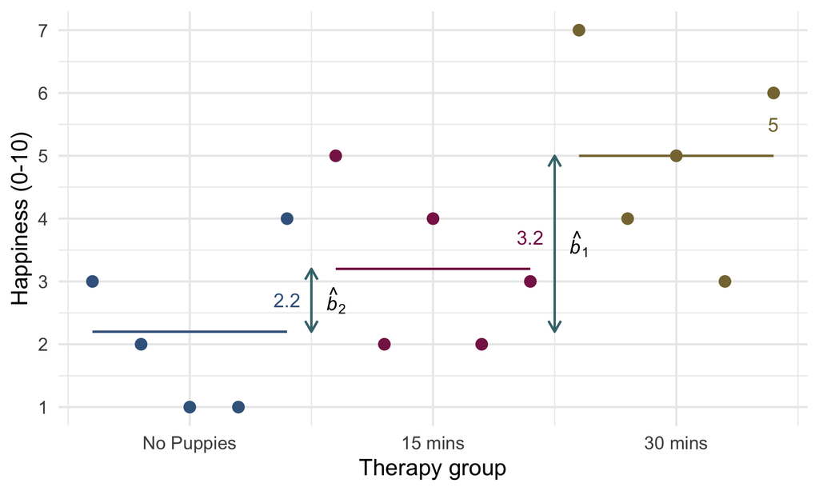

## Slide 54: Visualize the contrast model

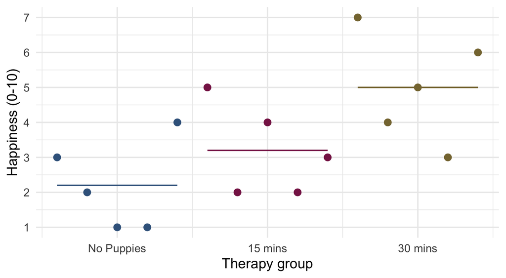

## Slide 55: Visualize contrast 1

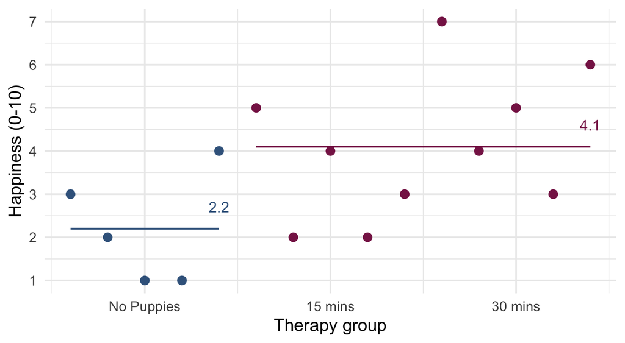

## Slide 56: Visualize contrast 1

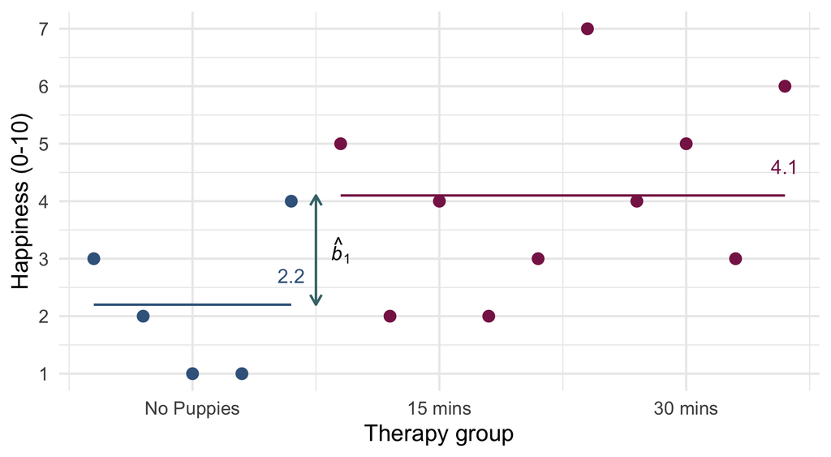

$$\begin{aligned} \hat{b}_1 &= 4.1-2.2 = 1.9 \end{aligned}$$

## Slide 57: Visualize contrast 2

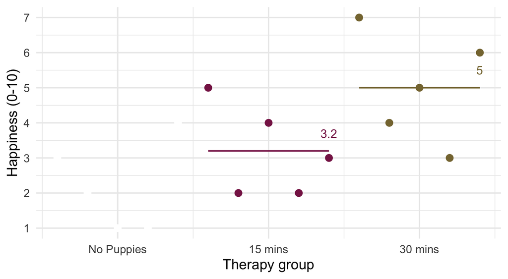

## Slide 58: Visualize contrast 2

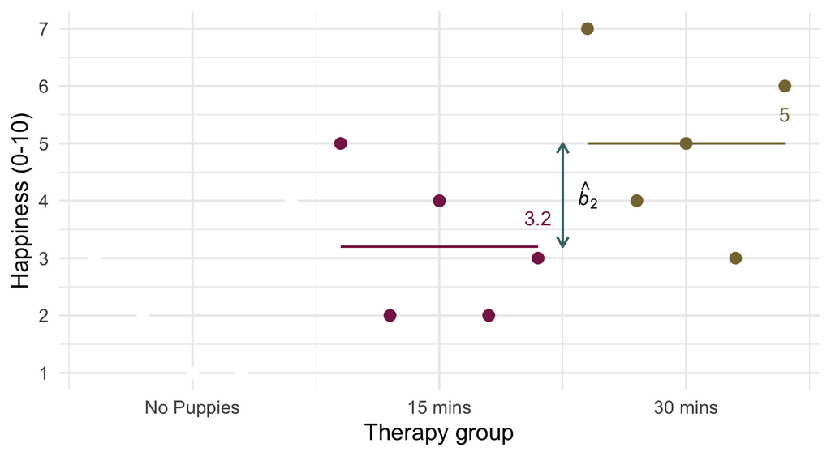

$$\begin{aligned} \hat{b}_2 &= 5-3.2 = 1.8 \end{aligned}$$

## Slide 59: Evaluate

> **Note: Statis-tip**
> - Changing the contrast codes will not affect the fit statistics or residual plots.

[figure not shown]

## Slide 60: Interpret parameter estimates, CIs and tests

```r
puppy_vs_none <- c(-2/3, 1/3, 1/3)
long_vs_short <- c(0, -1/2, 1/2)

contrasts(puppy_tib$dose) <- cbind(puppy_vs_none, long_vs_short)

puppy_lm <- lm(happiness ~ dose, data = puppy_tib)
model_parameters(puppy_lm) |>
  display()
```

| Parameter | Coefficient | SE | 95% CI | t(12) | p |
| --- | --- | --- | --- | --- | --- |
| (Intercept) | 3.47 | 0.36 | (2.68, 4.26) | 9.57 | < .001 |
| dose (puppy_vs_none) | 1.90 | 0.77 | (0.23, 3.57) | 2.47 | 0.029 |
| dose (long_vs_short) | 1.80 | 0.89 | (-0.13, 3.73) | 2.03 | 0.065 |

[figure not shown]

> **Important: ReportR**

## Slide 61

Video clip: [milton insert snow](https://profandyfield.github.io/statistics_lectures/ds_07_contrasts/media/milton_insert_snow.mp4)

## Slide 62: Post hoc tests

- In the absence of specific hypotheses
  - Compare all pairs of means to see where the specific differences lie
- Problem
  - Inflates the Type I error rate

$$\begin{aligned} \text{Familywise error} = 1-0.95^n \end{aligned}$$

- Solution
  - Adjust the alpha (or test statistic) to be more conservative

$$\begin{aligned} \text{Bonferroni} \ \alpha = \frac{\alpha}{\text{number of tests}} \end{aligned}$$

## Slide 63: Post hoc tests

```r
estimate_contrasts(puppy_lm, p_adjust = "bonferroni") |>
  display()
```

Marginal Contrasts Analysis

| Level1 | Level2 | Difference | SE | 95% CI | t(12) | p |
| --- | --- | --- | --- | --- | --- | --- |
| 15 mins | No puppies | 1.00 | 0.89 | (-0.93, 2.93) | 1.13 | 0.845 |
| 30 mins | No puppies | 2.80 | 0.89 | ( 0.87, 4.73) | 3.16 | 0.025 |
| 30 mins | 15 mins | 1.80 | 0.89 | (-0.13, 3.73) | 2.03 | 0.196 |

## Slide 64: Trend analysis (Polynomial contrasts)

- Test for trends in the means
- Makes sense only for ordered groups

```r
contrasts(puppy_tib$dose) <- contr.poly(3)
puppy_trend <- lm(happiness ~ dose, data = puppy_tib)

model_parameters(puppy_trend) |>
  display()
```

| Parameter | Coefficient | SE | 95% CI | t(12) | p |
| --- | --- | --- | --- | --- | --- |
| (Intercept) | 3.47 | 0.36 | (2.68, 4.26) | 9.57 | < .001 |
| dose (.L) | 1.98 | 0.63 | (0.61, 3.35) | 3.16 | 0.008 |
| dose (.Q) | 0.33 | 0.63 | (-1.04, 1.69) | 0.52 | 0.612 |

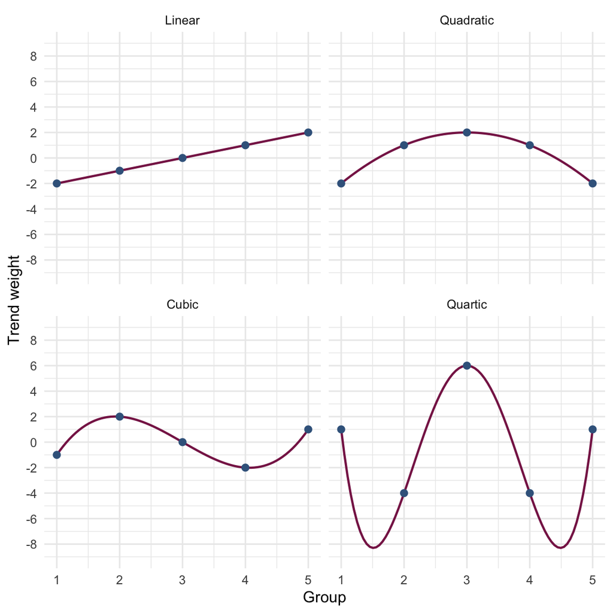

## Slide 65: Summary

- Categorical predictors can be coded to test specific a priori hypotheses
- First devise contrasts to test your hypotheses
  - Independent
  - *K*-1 contrasts
  - Each compares 2 ‘chunks’ -Assign ‘weights’ to each group within each contrast
  - Assign 1 chunk positive values and the other negative
  - Assign an initial weight equal to the number of conditions in the opposite chunk
  - Divide the initial weight by the number of groups with non-zero weights
- *Post hoc* tests
  - Compare all pairs of group means but adjusting for multiple tests
- Polynomial contrasts (trend analysis)
  - Test for trends in the means of ordered categories